# Did the Networks Lose Fairly?

ECON 8310: Business Forecasting — a second look at the scoreboard

Every neural network in this course finished behind a 46-coefficient LASSO. We re-ran all four with fairer training and more information, to find out whether the architectures lost or the setup did.

**Short answer: mostly the setup.**

- **Training order mattered most.** Every lab fed its network the training windows one series at a time. Shuffling them between batches, which is safe once the data is split by time, improved all four networks.
- **The LSTM needed far longer training** than the labs gave it: about 140 epochs instead of 30.
- **Extra features helped little.** Next week’s price and SNAP days were already in the window the networks read.
- **The best network now ties the LASSO.** An RNN with all the extra features scored 743 against the LASSO’s 744. No network clearly beats it.

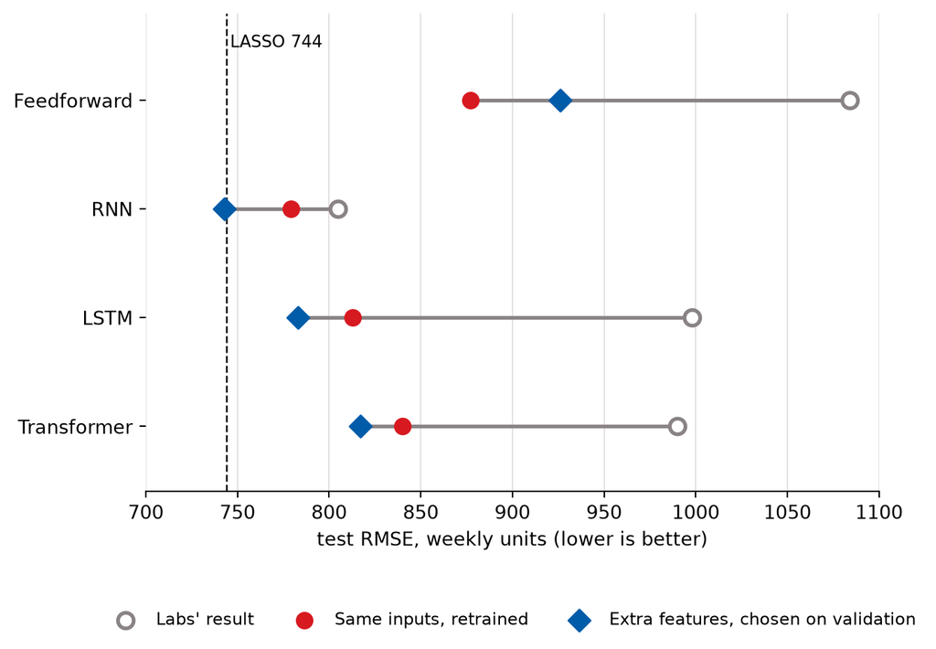

*Each marker is the mean of three training runs with different random seeds. “Retrained” means shuffled training batches and a training length chosen on a validation block. Seasonal naive, the benchmark, sits far off the right edge at 2,152.*

# The question

The course scoreboard ranks every method on the same 30 weekly sales series and the same 53 test weeks. A LASSO with 46 hand-built features scored 744. The best neural network, a plain RNN, scored 805, and the LSTM and Transformer came in near 1,000.

That gap could mean the networks are the wrong tool for this data. It could also mean we trained them badly or gave them less to work with. The LASSO knew which store and category it was forecasting, and it knew the forecast week’s own SNAP days, events and price. The networks knew neither. This experiment separates those explanations.

# What stayed the same

- **Data:** the M5 weekly panel, 30 series (10 stores × 3 categories), units sold per week.
- **Split:** train on weeks before 17 May 2015; test on the 53 weeks after it, 1,590 forecasts in all. This is the same test block as Homework 4’s LASSO.
- **Models:** the exact networks from the labs: Lab 7’s feedforward network (26-week window), Lab 9 Part 1’s RNN and LSTM, and Lab 9 Part 2’s Transformer (52-week windows), all with the labs’ sizes and optimizer settings.
- **Seeds:** every result is the mean of three runs with seeds 1, 2 and 3, reported as mean ± standard deviation.

# Step 1: reproduce the labs first

Before changing anything, we re-ran each lab’s model exactly as the lab does. If those numbers had not matched, any later comparison would mean nothing.

| Model | Lab’s recorded result | Our re-run |
| --- | --- | --- |
| Feedforward, 60 epochs | 1,109 · 1,176 · 946 | 1,109 · 1,176 · 946 |
| RNN, 30 epochs | 805 (seeds 1–2) | 805 |
| LSTM, 30 epochs | 998 (seeds 1–2) | 998 |
| Transformer, 30 epochs | 1,013 · 967 | 1,013 · 967 |

All four matched. Every difference below comes from what we changed, not from a different setup.

# Step 2: change one thing at a time

## Training order

A PyTorch `DataLoader` with `shuffle=False` serves the training windows in the order they were built, series by series. Each batch then comes from a single store and category, and the model spends a stretch of every pass on one series before moving to the next. With `shuffle=True`, every batch mixes all 30 series.

Shuffling the training windows does not leak the future. Every training window still ends before the test period, and each window carries its own past. What leaks is shuffling or splitting at random *before* the time split. The labs used `shuffle=False` so that a run repeats exactly. A shuffled run with a fixed seed repeats exactly too: we ran the same shuffled RNN twice and got 752.591 both times.

## Training length, chosen honestly

The labs trained for a fixed 30 or 60 epochs. Picking a longer length because it scored best on the test weeks would quietly use the test set to tune the model. Instead we followed Lecture 7’s advice on early stopping and let a validation block decide:

1. Set aside the last 52 weeks of the training period as a validation block.
2. Train on the weeks before it, and note the epoch with the lowest validation error.
3. Retrain on the whole training period for that many epochs, then score the test weeks once.

## Features

We gave each network the information the LASSO had, in groups:

- **Which series:** store and category as one-hot columns.
- **The forecast week itself:** its SNAP days, event days, price and week of the year, joined to the network’s final layer.
- **All of the above,** plus the week of the year for every week in the window.

Which feature set counts for each network was also chosen on the validation block, never on the test weeks.

# Results

## Training order, at the labs’ own training lengths

| Model | Lab order | Shuffled | Change |
| --- | --- | --- | --- |
| Feedforward (60 epochs) | 1,077 ± 96 | 893 ± 60 | −184 |
| RNN (30 epochs) | 820 ± 21 | 752 ± 1 | −68 |
| LSTM (30 epochs) | 997 ± 2 | 975 ± 0 | −22 |
| Transformer (30 epochs) | 950 ± 60 | 859 ± 30 | −91 |

*The lab-order rows here use three seeds, so the RNN shows 820 rather than the scoreboard’s two-seed 805.*

## Training length, shuffled, the labs’ inputs

| Model | 30 epochs | 60 | 100 | Chosen on validation | Epochs chosen |
| --- | --- | --- | --- | --- | --- |
| Feedforward | 850 | 893 | 890 | 877 ± 43 | 30–51 |
| RNN | 752 | 752 | 779 | 779 ± 2 | 62–97 |
| LSTM | 975 | 845 | 773 | 813 ± 14 | 139–148 of 150 |
| Transformer | 859 | 840 | 842 | 840 ± 22 | 43–98 |

## Features, shuffled, training length chosen on validation

| Model | Labs’ inputs | + series | + forecast week | All | Chosen on validation |
| --- | --- | --- | --- | --- | --- |
| Feedforward | 877 | 972 | 839 | 926 | 926 (all) |
| RNN | 779 | 789 | 781 | 743 | **743 (all)** |
| LSTM | 813 | 783 | 821 | 820 | 783 (+ series) |
| Transformer | 840 | · | · | 817 | 817 (all) |
| *LASSO, 46 features* |  |  |  |  | *744* |
| *XGBoost* |  |  |  |  | *781 (792 with the course’s pinned version)* |
| *Seasonal naive* |  |  |  |  | *2,152* |

*For the Transformer we ran only the labs’ inputs and the full feature set under validation, because each run takes several minutes.*